# Project: Investigate a Dataset - [US Census Data]

- Introduction
- Data Wrangling
- Exploratory Data Analysis
- Conclusions

## Introduction

### Dataset Description

> This dataset is from the 2016 US Census. This data will be used to help find trends in population growth. The data is listed by state and it contains data on population, ethnicity, housing, education, insurance, labor force, employment, sales, income, firm ownership and other characteristics of the average person of that state. The exact list of columns is as follows:

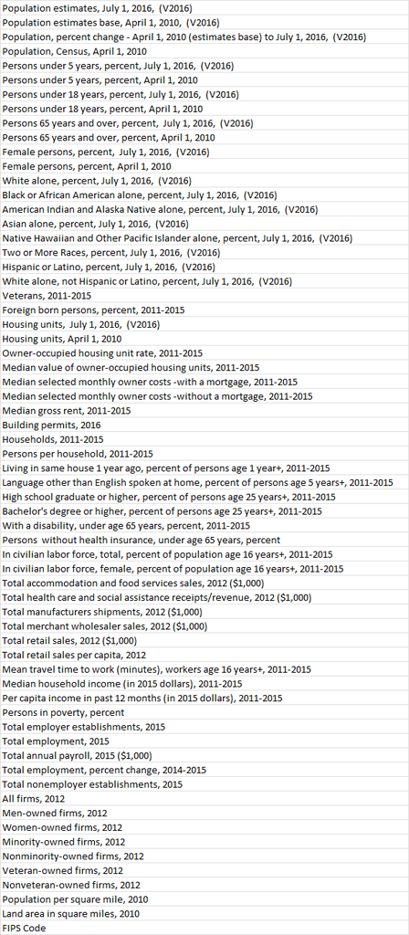

### Question(s) for Analysis

> Are states with smaller populations growing faster than those with larger populations by percent?

> Do states with higher median household income have greater population growth?

> If there is a higher percent of foreign born people is the population growth higher?

```python
import numpy as np
import pandas as pd
import matplotlib.pyplot as plt
import seaborn as sns
%matplotlib inline
```

## Data Wrangling

### General Properties

```python
cd = pd.read_csv("US_Census_Data.csv", index_col='Fact')
cd.head()
```

| Fact | Fact Note | Alabama | Alaska | Arizona | Arkansas | California | Colorado | Connecticut | Delaware | Florida | ... | South Dakota | Tennessee | Texas | Utah | Vermont | Virginia | Washington | West Virginia | Wisconsin | Wyoming |
| --- | --- | --- | --- | --- | --- | --- | --- | --- | --- | --- | --- | --- | --- | --- | --- | --- | --- | --- | --- | --- | --- |
| Population estimates, July 1, 2016, (V2016) | NaN | 4,863,300 | 741,894 | 6,931,071 | 2,988,248 | 39,250,017 | 5,540,545 | 3,576,452 | 952,065 | 20,612,439 | ... | 865454 | 6651194 | 27,862,596 | 3,051,217 | 624,594 | 8,411,808 | 7,288,000 | 1,831,102 | 5,778,708 | 585,501 |
| Population estimates base, April 1, 2010, (V2016) | NaN | 4,780,131 | 710,249 | 6,392,301 | 2,916,025 | 37,254,522 | 5,029,324 | 3,574,114 | 897,936 | 18,804,592 | ... | 814195 | 6346298 | 25,146,100 | 2,763,888 | 625,741 | 8,001,041 | 6,724,545 | 1,853,011 | 5,687,289 | 563,767 |
| Population, percent change - April 1, 2010 (estimates base) to July 1, 2016, (V2016) | NaN | 1.70% | 4.50% | 8.40% | 2.50% | 5.40% | 10.20% | 0.10% | 6.00% | 9.60% | ... | 0.063 | 0.048 | 10.80% | 10.40% | -0.20% | 5.10% | 8.40% | -1.20% | 1.60% | 3.90% |
| Population, Census, April 1, 2010 | NaN | 4,779,736 | 710,231 | 6,392,017 | 2,915,918 | 37,253,956 | 5,029,196 | 3,574,097 | 897,934 | 18,801,310 | ... | 814180 | 6346105 | 25,145,561 | 2,763,885 | 625,741 | 8,001,024 | 6,724,540 | 1,852,994 | 5,686,986 | 563,626 |
| Persons under 5 years, percent, July 1, 2016, (V2016) | NaN | 6.00% | 7.30% | 6.30% | 6.40% | 6.30% | 6.10% | 5.20% | 5.80% | 5.50% | ... | 0.071 | 0.061 | 7.20% | 8.30% | 4.90% | 6.10% | 6.20% | 5.50% | 5.80% | 6.50% |

5 rows × 51 columns

Since the data I will be looking at is the state characteristics I will have to change the rows to columns and the columns to rows to make the data easier to work with.

```python
cd.shape
```

```
(85, 51)
```

There are 85 rows which are state characteristics and 51 columns which are states. There is one extra column that will need to be removed.

```python
cd.info()
```

```
<class 'pandas.core.frame.DataFrame'>
Index: 85 entries, Population estimates, July 1, 2016,  (V2016) to Z
Data columns (total 51 columns):
 #   Column          Non-Null Count  Dtype
---  ------          --------------  -----
 0   Fact Note       28 non-null     object
 1   Alabama         65 non-null     object
 2   Alaska          65 non-null     object
 3   Arizona         65 non-null     object
 4   Arkansas        65 non-null     object
 5   California      65 non-null     object
 6   Colorado        65 non-null     object
 7   Connecticut     65 non-null     object
 8   Delaware        65 non-null     object
 9   Florida         65 non-null     object
```

[output cut: 43 more lines]

Looking the non-null values it seems that there is something wrong because there are 85 columns but only 65 values listed for each state. It is most likely because extra data that was not part of the table was read from the csv file. It also looks like all the data is listed as a strings when I need the data to be either integers or floats so that will have to be changed as well.

```python
cd.tail()
```

| Fact | Fact Note | Alabama | Alaska | Arizona | Arkansas | California | Colorado | Connecticut | Delaware | Florida | ... | South Dakota | Tennessee | Texas | Utah | Vermont | Virginia | Washington | West Virginia | Wisconsin | Wyoming |
| --- | --- | --- | --- | --- | --- | --- | --- | --- | --- | --- | --- | --- | --- | --- | --- | --- | --- | --- | --- | --- | --- |
| FN | Footnote on this item in place of data | NaN | NaN | NaN | NaN | NaN | NaN | NaN | NaN | NaN | ... | NaN | NaN | NaN | NaN | NaN | NaN | NaN | NaN | NaN | NaN |
| NaN | Not available | NaN | NaN | NaN | NaN | NaN | NaN | NaN | NaN | NaN | ... | NaN | NaN | NaN | NaN | NaN | NaN | NaN | NaN | NaN | NaN |
| S | Suppressed; does not meet publication standards | NaN | NaN | NaN | NaN | NaN | NaN | NaN | NaN | NaN | ... | NaN | NaN | NaN | NaN | NaN | NaN | NaN | NaN | NaN | NaN |
| X | Not applicable | NaN | NaN | NaN | NaN | NaN | NaN | NaN | NaN | NaN | ... | NaN | NaN | NaN | NaN | NaN | NaN | NaN | NaN | NaN | NaN |
| Z | Value greater than zero but less than half uni... | NaN | NaN | NaN | NaN | NaN | NaN | NaN | NaN | NaN | ... | NaN | NaN | NaN | NaN | NaN | NaN | NaN | NaN | NaN | NaN |

5 rows × 51 columns

I have confirmed that there are notes that were read from the csv file that will have to be cleaned.

### Data Cleaning

I will now transpose the table so that the states are listed as rows and the columns are the state characteristics.

```python
cdt = cd.transpose()
cdt.head()
```

| Fact | Population estimates, July 1, 2016, (V2016) | Population estimates base, April 1, 2010, (V2016) | Population, percent change - April 1, 2010 (estimates base) to July 1, 2016, (V2016) | Population, Census, April 1, 2010 | Persons under 5 years, percent, July 1, 2016, (V2016) | Persons under 5 years, percent, April 1, 2010 | Persons under 18 years, percent, July 1, 2016, (V2016) | Persons under 18 years, percent, April 1, 2010 | Persons 65 years and over, percent, July 1, 2016, (V2016) | Persons 65 years and over, percent, April 1, 2010 | ... | NaN | Value Flags | - | D | F | FN | NaN | S | X | Z |
| --- | --- | --- | --- | --- | --- | --- | --- | --- | --- | --- | --- | --- | --- | --- | --- | --- | --- | --- | --- | --- | --- |
| Fact Note | NaN | NaN | NaN | NaN | NaN | NaN | NaN | NaN | NaN | NaN | ... | NaN | NaN | Either no or too few sample observations were ... | Suppressed to avoid disclosure of confidential... | Fewer than 25 firms | Footnote on this item in place of data | Not available | Suppressed; does not meet publication standards | Not applicable | Value greater than zero but less than half uni... |
| Alabama | 4,863,300 | 4,780,131 | 1.70% | 4,779,736 | 6.00% | 6.40% | 22.60% | 23.70% | 16.10% | 13.80% | ... | NaN | NaN | NaN | NaN | NaN | NaN | NaN | NaN | NaN | NaN |
| Alaska | 741,894 | 710,249 | 4.50% | 710,231 | 7.30% | 7.60% | 25.20% | 26.40% | 10.40% | 7.70% | ... | NaN | NaN | NaN | NaN | NaN | NaN | NaN | NaN | NaN | NaN |
| Arizona | 6,931,071 | 6,392,301 | 8.40% | 6,392,017 | 6.30% | 7.10% | 23.50% | 25.50% | 16.90% | 13.80% | ... | NaN | NaN | NaN | NaN | NaN | NaN | NaN | NaN | NaN | NaN |
| Arkansas | 2,988,248 | 2,916,025 | 2.50% | 2,915,918 | 6.40% | 6.80% | 23.60% | 24.40% | 16.30% | 14.40% | ... | NaN | NaN | NaN | NaN | NaN | NaN | NaN | NaN | NaN | NaN |

5 rows × 85 columns

```python
cdt.shape
```

```
(51, 85)
```

There are 51 rows which are the states and there are 85 columns which are the state charactersitics. There is one additional row because there is the Fact Note row. Since I only need the states and a few of the state characteristics I will remove Fact Note and all state characteristics not related to the questions I am trying to answer. I will also rename the columns so that they are not so long.

```python
ccd = cdt.iloc[1:51, [0, 2, 21, 47]]
ccd.rename(columns={'Population estimates, July 1, 2016,  (V2016)': 'Population', 'Population, percent change - April 1, 2010 (estimates base) to July 1, 2016,  (V2016)': 'Population % change', 'Foreign born persons, percent, 2011-2015': 'Foreign born %', 'Median household income (in 2015 dollars), 2011-2015': 'Household income'}, inplace=True)
ccd.head()
```

| Fact | Population | Population % change | Foreign born % | Household income |
| --- | --- | --- | --- | --- |
| Alabama | 4,863,300 | 1.70% | 3.50% | $43,623 |
| Alaska | 741,894 | 4.50% | 7.40% | $72,515 |
| Arizona | 6,931,071 | 8.40% | 13.50% | $50,255 |
| Arkansas | 2,988,248 | 2.50% | 4.70% | $41,371 |
| California | 39,250,017 | 5.40% | 27.00% | $61,818 |

I will now change the datatypes to integers or floats so that I can perform calculations on them.

```python
def transform(col):
    col = col.str.replace(',', '').str.replace('$', '')
    col = pd.to_numeric(col)
    return col
```

```python
def to_percent(col):
    col = col.str.replace('%', '')
    col = pd.to_numeric(col)
    col = col / 100
    return col
```

```python
ccd['Population'] = transform(ccd["Population"])
ccd['Household income'] = transform(ccd["Household income"])
ccd['Population % change'] = to_percent(ccd["Population % change"])
ccd['Foreign born %'] = to_percent(ccd["Foreign born %"])
ccd.info()
```

```
<class 'pandas.core.frame.DataFrame'>
Index: 50 entries, Alabama to Wyoming
Data columns (total 4 columns):
 #   Column               Non-Null Count  Dtype
---  ------               --------------  -----
 0   Population           50 non-null     int64
 1   Population % change  50 non-null     float64
 2   Foreign born %       50 non-null     float64
 3   Household income     50 non-null     int64
dtypes: float64(2), int64(2)
memory usage: 2.0+ KB
```

The data has now been cleaned. The rows now contain only states. The columns contain state characteristics and the datatypes are integers and floats.

## Exploratory Data Analysis

### Research Question 1

### (Are states with smaller populations growing faster than those with larger populations by percent?)

First to get a sense of the data I will look over basic statistics for each column.

```python
ccd.describe()
```

| Fact | Population | Population % change | Foreign born % | Household income |
| --- | --- | --- | --- | --- |
| count | 5.000000e+01 | 50.000000 | 50.000000 | 50.000000 |
| mean | 6.448927e+06 | 0.031207 | 0.070770 | 54311.860000 |
| std | 7.271769e+06 | 0.033669 | 0.067516 | 8949.529115 |
| min | 5.855010e+05 | -0.012000 | 0.000300 | 39665.000000 |
| 25% | 1.850106e+06 | 0.000692 | 0.016500 | 47526.000000 |
| 50% | 4.559320e+06 | 0.020500 | 0.048000 | 52601.000000 |
| 75% | 7.198768e+06 | 0.050750 | 0.112250 | 60599.000000 |
| max | 3.925002e+07 | 0.108000 | 0.270000 | 74551.000000 |

> For population it looks like the mean is around 6.5 million and it ranges from around 600,000 to 40,000,000.

> For Population % change the mean is 3.12% and the range is -1.2% to 10.8%.

> For Foreign born % the mean is 7.1% and the range is 0.03% to 27.0%.

> For Household income the mean is around 54,000 dollars and the range is about 40,000 to 75,000 dollars.

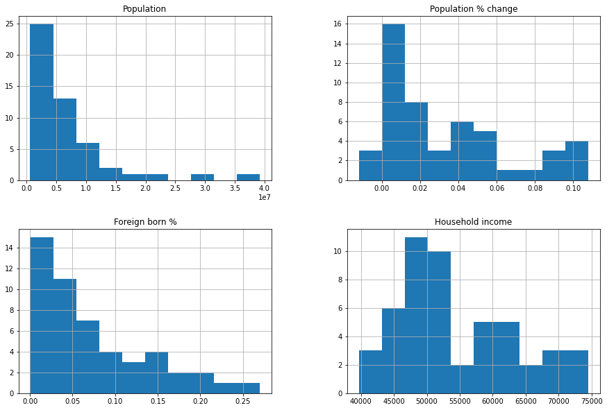

```python
ccd.hist(figsize=(15,10))
plt.show()
```

> Population is skewed right meanining that there are more states with smaller populations than larger populations.

> Population % change does not show an obvious distribution.

> This shows that the number of states with a foreign born % population is skewed right meaning that there are not that many states with a high population of foreigners.

> There does not seem to be an obvious distribution for Household income. The median does look to be around 50,000 dollars.

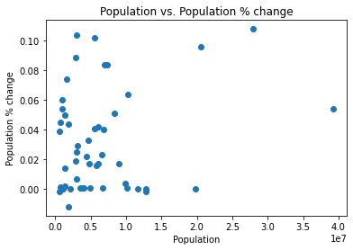

```python
x = ccd['Population']
y = ccd['Population % change']
plt.scatter(x, y)
plt.xlabel('Population')
plt.ylabel('Population % change')
plt.title('Population vs. Population % change')
plt.show()
```

There is a weak correlation between Population of a state and the Population % change. Otherwise the correlation looks to be positive. From this graph it is also obvious how many states have smaller populations.

### Research Question 2

#### (How does the % of foreign born population and median household income correlate to population growth?)

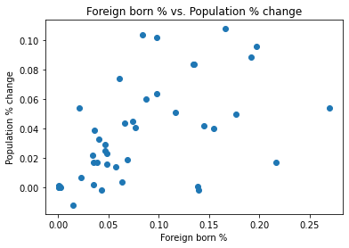

```python
x = ccd['Foreign born %']
y = ccd['Population % change']
plt.scatter(x, y)
plt.xlabel('Foreign born %')
plt.ylabel('Population % change')
plt.title('Foreign born % vs. Population % change')
plt.show()
```

There is a positive correlation between Population % change and Foreign born %. There is a cluster in the lower left of the scatter plot and it slowly expands outwards in a cone like shape avoiding the edges of the scatterplot.

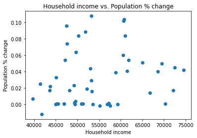

```python
x = ccd['Household income']
y = ccd['Population % change']
plt.scatter(x, y)
plt.xlabel('Household income')
plt.ylabel('Population % change')
plt.title('Household income vs. Population % change')
plt.show()
```

There is a weak correlation or no correlation. It could be said states with a median household incomes that are more average have higher population growth. This is based off of the fact that there are no states at the top left or top right corner of the scatter plot.

## Conclusions

### Limitation

> The limitations of this data are that the data for population did not take into account how large the state was which would eliminate population density as a factor that could be affecting the results being produced, and for household income it would be more accurate to use data that is the average income of a person in that state because there may be differences in the type of households between states.